# Finanance DA Capstone Solution

```python
import pandas as pd
import numpy as np
import re
import warnings
warnings.filterwarnings('ignore')
import matplotlib.pyplot as plt
import seaborn as sns
import scipy.stats as stats
import datetime as dt
import dateutil.relativedelta as rd
from sklearn.model_selection import train_test_split as split
from sklearn.linear_model import LogisticRegression
from sklearn.metrics import classification_report, accuracy_score
plt.style.use('ggplot')
```

```python
data = pd.read_excel('data.xlsx')
```

## Preliminary analysis:

- Perform preliminary data inspection and report the findings as the structure of the data, missing values, duplicates etc.
- The variable names in the data are not in accordance with the identifier naming in Python. Change the variable names accordingly.

```python
data.info()
```

```
<class 'pandas.core.frame.DataFrame'>
RangeIndex: 233154 entries, 0 to 233153
Data columns (total 41 columns):
UniqueID                               233154 non-null int64
disbursed_amount                       233154 non-null int64
asset_cost                             233154 non-null int64
ltv                                    233154 non-null float64
branch_id                              233154 non-null int64
supplier_id                            233154 non-null int64
manufacturer_id                        233154 non-null int64
Current_pincode_ID                     233154 non-null int64
Date.of.Birth                          233154 non-null datetime64[ns]
Employment.Type                        225493 non-null object
DisbursalDate                          233154 non-null datetime64[ns]
State_ID                               233154 non-null int64
Employee_code_ID                       233154 non-null int64
MobileNo_Avl_Flag                      233154 non-null int64
Aadhar_flag                            233154 non-null int64
PAN_flag                               233154 non-null int64
VoterID_flag                           233154 non-null int64
Driving_flag                           233154 non-null int64
Passport_flag                          233154 non-null int64
PERFORM_CNS.SCORE                      233154 non-null int64
PERFORM_CNS.SCORE.DESCRIPTION          233154 non-null object
PRI.NO.OF.ACCTS                        233154 non-null int64
PRI.ACTIVE.ACCTS                       233154 non-null int64
PRI.OVERDUE.ACCTS                      233154 non-null int64
PRI.CURRENT.BALANCE                    233154 non-null int64
PRI.SANCTIONED.AMOUNT                  233154 non-null int64
PRI.DISBURSED.AMOUNT                   233154 non-null int64
SEC.NO.OF.ACCTS                        233154 non-null int64
SEC.ACTIVE.ACCTS                       233154 non-null int64
SEC.OVERDUE.ACCTS                      233154 non-null int64
SEC.CURRENT.BALANCE                    233154 non-null int64
SEC.SANCTIONED.AMOUNT                  233154 non-null int64
SEC.DISBURSED.AMOUNT                   233154 non-null int64
PRIMARY.INSTAL.AMT                     233154 non-null int64
SEC.INSTAL.AMT                         233154 non-null int64
NEW.ACCTS.IN.LAST.SIX.MONTHS           233154 non-null int64
DELINQUENT.ACCTS.IN.LAST.SIX.MONTHS    233154 non-null int64
AVERAGE.ACCT.AGE                       233154 non-null object
CREDIT.HISTORY.LENGTH                  233154 non-null object
NO.OF_INQUIRIES                        233154 non-null int64
loan_default                           233154 non-null int64
dtypes: datetime64[ns](2), float64(1), int64(34), object(4)
memory usage: 72.9+ MB
```

#### column names need to be changed

```python
data.columns = data.columns.str.replace('.','_').str.lower()
```

```python
print('Are there any duplicated rows ??',data.duplicated().any())
```

```
Are there any duplicated rows ?? False
```

## missing values

```python
print('Missing values in variable')
print(data.isnull().sum())
```

```
Missing values in variable
uniqueid                                  0
disbursed_amount                          0
asset_cost                                0
ltv                                       0
branch_id                                 0
supplier_id                               0
manufacturer_id                           0
current_pincode_id                        0
date_of_birth                             0
employment_type                        7661
disbursaldate                             0
state_id                                  0
employee_code_id                          0
mobileno_avl_flag                         0
aadhar_flag                               0
pan_flag                                  0
voterid_flag                              0
driving_flag                              0
passport_flag                             0
perform_cns_score                         0
perform_cns_score_description             0
pri_no_of_accts                           0
pri_active_accts                          0
pri_overdue_accts                         0
pri_current_balance                       0
pri_sanctioned_amount                     0
pri_disbursed_amount                      0
sec_no_of_accts                           0
sec_active_accts                          0
sec_overdue_accts                         0
sec_current_balance                       0
sec_sanctioned_amount                     0
sec_disbursed_amount                      0
primary_instal_amt                        0
sec_instal_amt                            0
new_accts_in_last_six_months              0
delinquent_accts_in_last_six_months       0
average_acct_age                          0
credit_history_length                     0
no_of_inquiries                           0
loan_default                              0
dtype: int64
```

```python
#Checking Missing Values
missing_vars = pd.DataFrame(data.isnull().sum())
missing_vars.columns = ["count"]
missing_vars.loc[missing_vars["count"] > 0]
```

|  | count |
| --- | --- |
| employment_type | 7661 |

## Provide the statistical description of the numerical data variables

## exploring the unique ids

```python
id_data =[  'uniqueid', 'branch_id', 'state_id', 'manufacturer_id', 'current_pincode_id', 'state_id', 'employee_code_id']
```

```python
for i in id_data:
    print('No. of Unique values for {} : \n{}'.format(i.upper(),data[i].nunique()) )
```

```
No. of Unique values for UNIQUEID :
233154
No. of Unique values for BRANCH_ID :
82
No. of Unique values for STATE_ID :
22
No. of Unique values for MANUFACTURER_ID :
11
No. of Unique values for CURRENT_PINCODE_ID :
6698
No. of Unique values for STATE_ID :
22
No. of Unique values for EMPLOYEE_CODE_ID :
3270
```

## Overall Statistical Description

### identifying categorical data :

```python
cat_cols = ['branch_id', 'supplier_id', 'manufacturer_id', 'state_id',
            'new_accts_in_last_six_months','delinquent_accts_in_last_six_months',
            'pri_no_of_accts', 'pri_active_accts','pri_overdue_accts',
            'sec_no_of_accts', 'sec_active_accts','sec_overdue_accts','average_acct_age']
for i in cat_cols :
    data[i] = data[i].astype('category')
```

```python
binary_columns = list(data.nunique()[data.nunique() == 2].index)
```

### description for categorical columns

```python
data.describe(include = 'category')
```

|  | branch_id | supplier_id | manufacturer_id | state_id | pri_no_of_accts | pri_active_accts | pri_overdue_accts | sec_no_of_accts | sec_active_accts | sec_overdue_accts | new_accts_in_last_six_months | delinquent_accts_in_last_six_months | average_acct_age |
| --- | --- | --- | --- | --- | --- | --- | --- | --- | --- | --- | --- | --- | --- |
| count | 233154 | 233154 | 233154 | 233154 | 233154 | 233154 | 233154 | 233154 | 233154 | 233154 | 233154 | 233154 | 233154 |
| unique | 82 | 2953 | 11 | 22 | 108 | 40 | 22 | 37 | 23 | 9 | 26 | 14 | 192 |
| top | 2 | 18317 | 86 | 4 | 0 | 0 | 0 | 0 | 0 | 0 | 0 | 0 | 0yrs 0mon |
| freq | 13138 | 1432 | 109534 | 44870 | 116950 | 137016 | 206879 | 227289 | 229337 | 231817 | 181494 | 214959 | 119373 |

### description for binary data using value counts

```python
for i in binary_columns:
    vc = data[i].value_counts()
    print(i.replace('_',' ').upper(), ':')
    for j in vc.index :
        print(j ,':', vc[j])
```

```
EMPLOYMENT TYPE :
Self employed : 127635
Salaried : 97858
AADHAR FLAG :
1 : 195924
0 : 37230
PAN FLAG :
0 : 215533
1 : 17621
VOTERID FLAG :
0 : 199360
1 : 33794
DRIVING FLAG :
0 : 227735
1 : 5419
PASSPORT FLAG :
0 : 232658
1 : 496
LOAN DEFAULT :
0 : 182543
1 : 50611
```

### describe quantitative data

```python
col = cat_cols + binary_columns

quant = data.loc[:,~data.columns.isin(col)]

quant.describe().loc[['min','25%','mean','50%','75%','max','std']].round(1)
```

|  | uniqueid | disbursed_amount | asset_cost | ltv | current_pincode_id | employee_code_id | mobileno_avl_flag | perform_cns_score | pri_current_balance | pri_sanctioned_amount | pri_disbursed_amount | sec_current_balance | sec_sanctioned_amount | sec_disbursed_amount | primary_instal_amt | sec_instal_amt | no_of_inquiries |
| --- | --- | --- | --- | --- | --- | --- | --- | --- | --- | --- | --- | --- | --- | --- | --- | --- | --- |
| min | 417428.0 | 13320.0 | 37000.0 | 10.0 | 1.0 | 1.0 | 1.0 | 0.0 | -6678296.0 | 0.000000e+00 | 0.000000e+00 | -574647.0 | 0.0 | 0.0 | 0.0 | 0.0 | 0.0 |
| 25% | 476786.2 | 47145.0 | 65717.0 | 68.9 | 1511.0 | 713.0 | 1.0 | 0.0 | 0.0 | 0.000000e+00 | 0.000000e+00 | 0.0 | 0.0 | 0.0 | 0.0 | 0.0 | 0.0 |
| mean | 535917.6 | 54357.0 | 75865.1 | 74.7 | 3396.9 | 1549.5 | 1.0 | 289.5 | 165900.1 | 2.185039e+05 | 2.180659e+05 | 5427.8 | 7295.9 | 7180.0 | 13105.5 | 323.3 | 0.2 |
| 50% | 535978.5 | 53803.0 | 70946.0 | 76.8 | 2970.0 | 1451.0 | 1.0 | 0.0 | 0.0 | 0.000000e+00 | 0.000000e+00 | 0.0 | 0.0 | 0.0 | 0.0 | 0.0 | 0.0 |
| 75% | 595039.8 | 60413.0 | 79201.8 | 83.7 | 5677.0 | 2362.0 | 1.0 | 678.0 | 35006.5 | 6.250000e+04 | 6.080000e+04 | 0.0 | 0.0 | 0.0 | 1999.0 | 0.0 | 0.0 |
| max | 671084.0 | 990572.0 | 1628992.0 | 95.0 | 7345.0 | 3795.0 | 1.0 | 890.0 | 96524920.0 | 1.000000e+09 | 1.000000e+09 | 36032852.0 | 30000000.0 | 30000000.0 | 25642806.0 | 4170901.0 | 36.0 |
| std | 68315.7 | 12971.3 | 18944.8 | 11.5 | 2238.1 | 975.3 | 0.0 | 338.4 | 942273.6 | 2.374794e+06 | 2.377744e+06 | 170237.0 | 183156.0 | 182592.5 | 151367.9 | 15553.7 | 0.7 |

## unique Values in the data

```python
data.nunique()
```

```
uniqueid                               233154
disbursed_amount                        24565
asset_cost                              46252
ltv                                      6579
branch_id                                  82
supplier_id                              2953
manufacturer_id                            11
current_pincode_id                       6698
date_of_birth                           15433
employment_type                             2
disbursaldate                              84
state_id                                   22
employee_code_id                         3270
mobileno_avl_flag                           1
aadhar_flag                                 2
pan_flag                                    2
voterid_flag                                2
driving_flag                                2
passport_flag                               2
perform_cns_score                         573
perform_cns_score_description              20
pri_no_of_accts                           108
pri_active_accts                           40
pri_overdue_accts                          22
pri_current_balance                     71341
pri_sanctioned_amount                   44390
pri_disbursed_amount                    47909
sec_no_of_accts                            37
sec_active_accts                           23
sec_overdue_accts                           9
sec_current_balance                      3246
sec_sanctioned_amount                    2223
sec_disbursed_amount                     2553
primary_instal_amt                      28067
sec_instal_amt                           1918
new_accts_in_last_six_months               26
delinquent_accts_in_last_six_months        14
average_acct_age                          192
credit_history_length                     294
no_of_inquiries                            25
loan_default                                2
dtype: int64
```

# How is the target variable distributed overall?

```python
data.loan_default.value_counts()
```

```
0    182543
1     50611
Name: loan_default, dtype: int64
```

```python
def transform(x):
    if x == 1: return 'Defaulter'
    if x == 0: return 'Non-Defaulter'
data['loan_default_text'] = data.loan_default.apply(transform)
```

[output not shown]

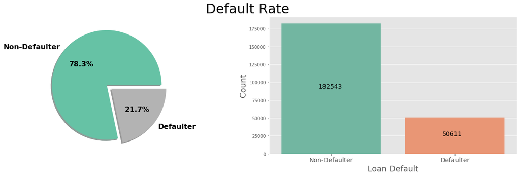

```python
f, axes = plt.subplots(1,2, figsize = (18,6))
vc = data.loan_default_text.value_counts()
vc.plot.pie(ax = axes[0], radius = 1, cmap = 'Set2' , explode = [0.01,0.1], shadow = True, autopct = '%1.1f%%',
           textprops = {'family': 'times','color': 'black','weight': 'bold','size': 16}, )
axes[0].set_ylabel('')
sns.countplot('loan_default_text', data = data, ax = axes[1], palette='Set2')
for i in range(len(vc)):
    axes[1].annotate(str(vc[i]), (i-0.1,(vc[i]/2)), fontsize = 14)
axes[1].set_ylim(0,axes[1].set_ylim()[1]+5)
axes[1].set_xlabel('Loan Default',fontsize = 18, family = 'times')
axes[1].set_ylabel('Count',fontsize = 18, family = 'times')
axes[1].set_xticklabels(axes[1].get_xticklabels(),fontsize = 14, family = 'times')
f.suptitle('Default Rate\n', fontsize = 30, family = 'times')
plt.tight_layout(pad = 4)
plt.show()
```

## Study the distribution of the target variable across the various categories such as branch, city, state, branch, supplier, manufacturer etc.

## Univariate Analysis and Variable vs Target

```python
def barplot(var):
    var_name = var.replace('_',' ').title()
    plt.figure(figsize = (20,5))
    sns.countplot(var,data = data, palette='Set2')
    plt.title(var_name+'\n',family='times', weight ='bold',fontsize= 25)
    plt.tight_layout()
    plt.xlabel(var_name,family='times',fontsize= 16)
    plt.ylabel('Frequency',family='georgia',fontsize= 16)
    plt.show()
```

```python
def cat_vs_target(var):
    var_name = var.replace('_',' ').title()
    plt.figure(figsize = (20,5))
    sns.countplot(var,hue = 'loan_default_text', data = data, palette='Set2')
    plt.title(var_name + ' vs Target',family='times', weight ='bold',fontsize= 25)
    plt.tight_layout()
    plt.xlabel(var_name ,family='times',fontsize= 16)
    plt.ylabel('Frequency',family='georgia',fontsize= 16)
    plt.show()
```

```python
# is the category and target dependent on each other??
def chi_test(var):
    ct = pd.crosstab(data[var], data.loan_default_text)
    st, p, df, ef = stats.chi2_contingency(ct)
    var_name = var.replace('_',' ')
    if p >= 0.05:
        text = ('{} and Target are independent'.format(var_name.title()))
    else :
        text = ('{} and Target are dependent'.format(var_name.title()))
    plt.figure(figsize = (1,1))
    plt.plot([0,0],[0,0])
    plt.xlim(0,50)
    plt.ylim(0,5)
    plt.axis('off')
    plt.annotate(text,xy = (2.5,2.5), fontsize= 25 )
    plt.show()
```

# 1. branch_id

[output not shown]

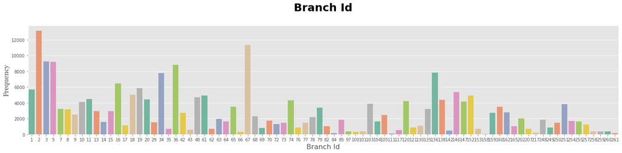

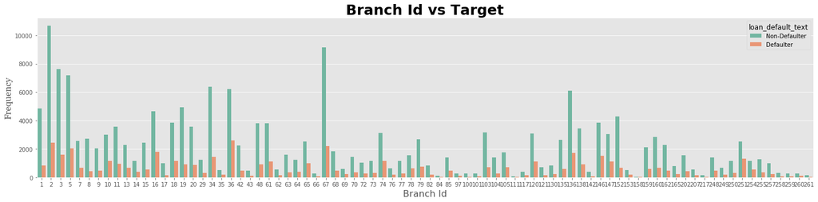

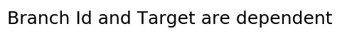

```python
var = 'branch_id'
barplot(var)
cat_vs_target(var)
chi_test(var)
```

## 2. Supplier Ids

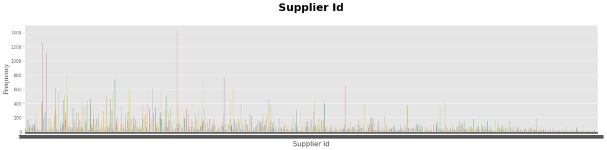

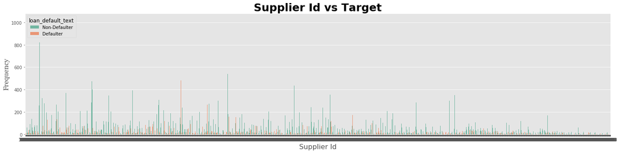

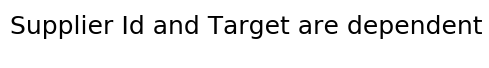

```python
var = 'supplier_id'
barplot(var)
cat_vs_target(var)
chi_test(var)
```

## 3. manufacturer_id

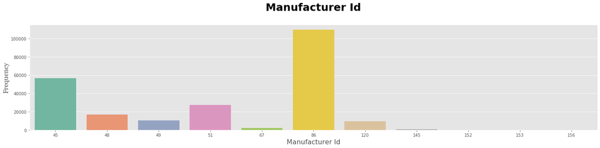

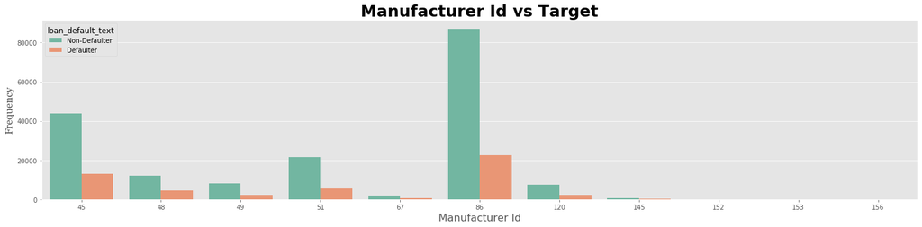

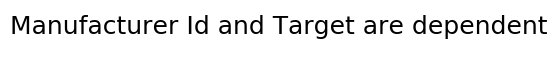

```python
var = 'manufacturer_id'
barplot(var)
cat_vs_target(var)
chi_test(var)
```

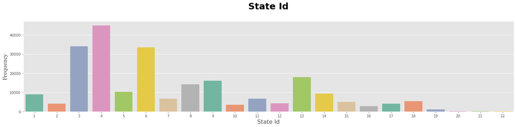

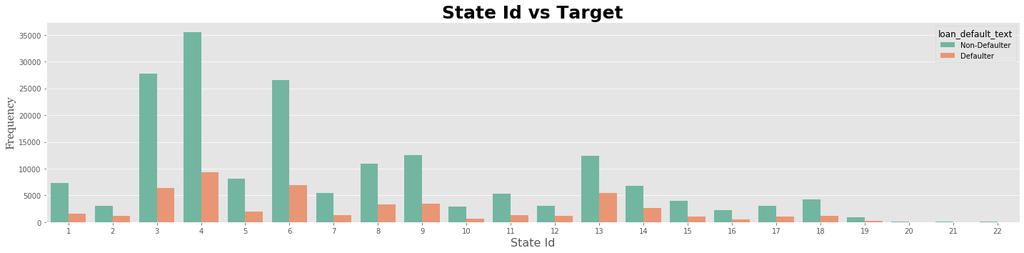

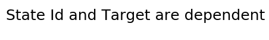

```python
var = 'state_id'
barplot(var)
cat_vs_target(var)
chi_test(var)
```

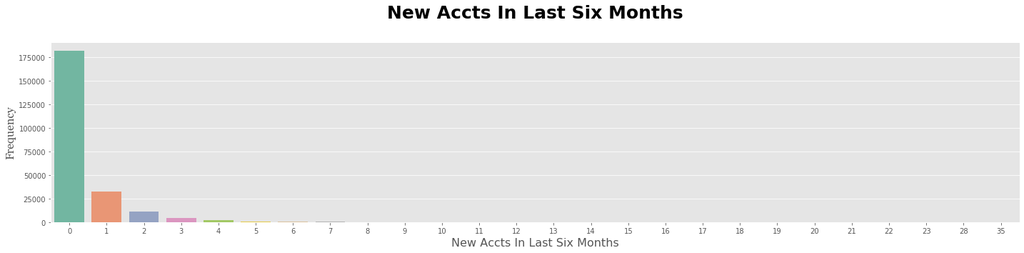

```python
var = 'new_accts_in_last_six_months'
barplot(var)
```

## What are the different employment type given in the data? Can a strategy be developed to fill in the missing values (if any)? How does employment type define defaulters and non-defaulters? Use pie charts to express.

## For Missing values : Employment Type

#### Only employment_type var has nulls

```python
# Checking unique values
print("Distinct Emp Type :",data.employment_type.unique())
#Checking missing valus in percentage
print("Missing Emp Type {:.2f} %".format(data.employment_type.isnull().sum() / len(data) * 100))
```

```
Distinct Emp Type : ['Salaried' 'Self employed' nan]
Missing Emp Type 3.29 %
```

## Few ways to fill in the missing values :

```
- Remove the rows as it is a very low percentage
- fill with modal values
- fill with a third type as other
```

```
- For this analysis the unique values in the Variable include Self Employed and Salaried. There may be applicants may be unemployed. So it seems logical to fill the missing values with 'Unemployed'
```

```python
data.employment_type.fillna('Unemployed',inplace = True)
```

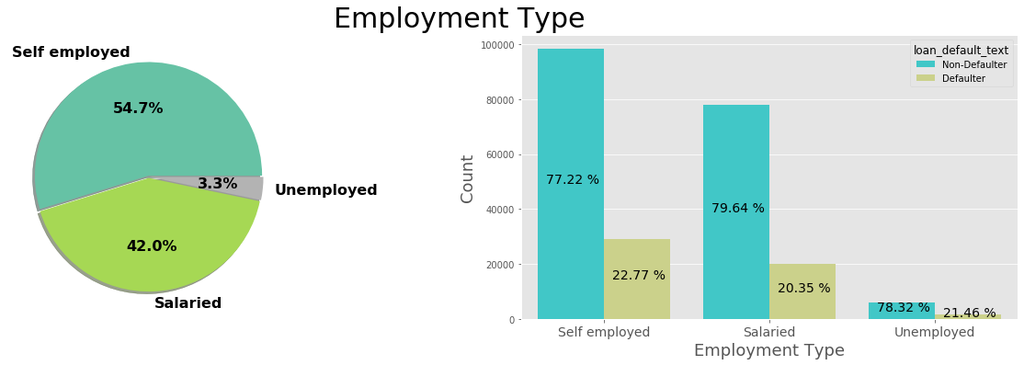

```python
var = 'employment_type'
var_name = var.replace('_',' ').title()
f, axes = plt.subplots(1,2, figsize = (18,6))
vc = data[var].value_counts()
vc.plot.pie(ax = axes[0], radius = 1, cmap = 'Set2' , explode = [0.01,0.01, 0.01], shadow = True, autopct = '%1.1f%%',
           textprops = {'family': 'times','color': 'black','weight': 'bold','size': 16}, )
axes[0].set_ylabel('')

sns.countplot(x = var, data = data, hue = 'loan_default_text',ax = axes[1], palette='rainbow', order = vc.index)
axes[1].set_ylim(0,axes[1].set_ylim()[1]+5)
axes[1].set_xlabel(var_name,fontsize = 18, family = 'times')
axes[1].set_ylabel('Count',fontsize = 18, family = 'times')
axes[1].set_xticklabels(axes[1].get_xticklabels(),fontsize = 14, family = 'times')
vc2 = pd.crosstab(data[var], data.loan_default_text).loc[vc.index]
vc2['Perc_Def'] = (vc2.Defaulter/vc2.sum(axis = 1)*100).round(2)
vc2['Perc_NDef'] = (vc2['Non-Defaulter']/vc2.sum(axis = 1)*100).round(2)
for i in range(len(vc2.index)):
    axes[1].annotate(str(vc2.iloc[i]['Perc_NDef'])+' %', (i - 0.35,vc2.iloc[i]['Non-Defaulter']/2+10), fontsize = 14)
    axes[1].annotate(str(vc2.iloc[i]['Perc_Def'])+' %', (i + 0.05,vc2.iloc[i]['Defaulter']/2+10), fontsize = 14)
f.suptitle(var_name , fontsize = 30, family = 'times')
plt.tight_layout(pad = 4)
plt.show()
```

## Has age got something to do with defaulting ? what is the distribution of age w.r.t. to defaulters and non-defaulters?

## Age in years as on disbursal date

```python
data['age_on_disbursal'] = data.apply(lambda row : rd.relativedelta(row.disbursaldate,row.date_of_birth).years, axis = 1)
```

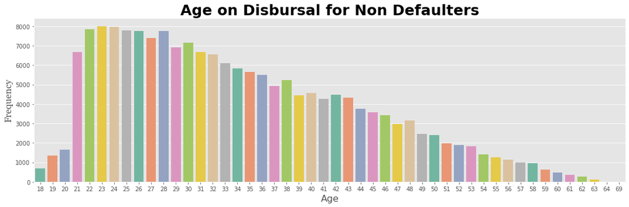

```python
plt.figure(figsize = (15,5))
sns.countplot('age_on_disbursal', data = data[data.loan_default ==0],palette='Set2')
plt.title('Age on Disbursal for Non Defaulters',family='times', weight ='bold',fontsize= 25)
plt.tight_layout( )
plt.xlabel('Age',family='times',fontsize= 16)
plt.ylabel('Frequency',family='georgia',fontsize= 16)
plt.show()
```

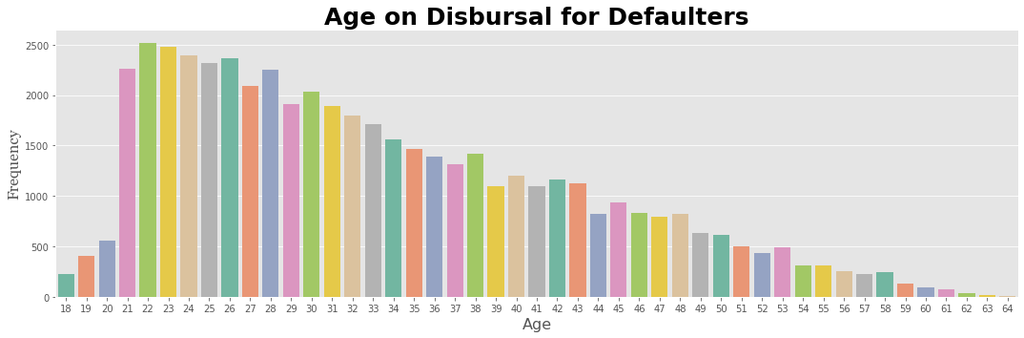

```python
plt.figure(figsize = (15,5))
sns.countplot('age_on_disbursal', data = data[data.loan_default ==1],palette='Set2')
plt.title('Age on Disbursal for Defaulters',family='times', weight ='bold',fontsize= 25)
plt.tight_layout( )
plt.xlabel('Age',family='times',fontsize= 16)
plt.ylabel('Frequency',family='georgia',fontsize= 16)
plt.show()
```

# What id type was presented by most of the customers as proofs?

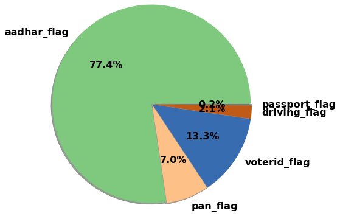

```python
counts = data[['aadhar_flag', 'pan_flag', 'voterid_flag',
       'driving_flag', 'passport_flag']].sum()

plt.figure(figsize =(20,5))
counts.plot.pie(cmap ='Accent', autopct = '%0.1f%%', radius = 1.5, explode = [0.01]*len(counts), shadow = True,
                    textprops = {'family': 'times','color': 'black','weight': 'bold','size': 16})
plt.ylabel('')
plt.show()
```

## a. Study the credit bureau score distribution. How is the distribution for defaulters vs non defaulters? Explore in detail.

```python
data[['perform_cns_score', 'perform_cns_score_description']]
```

|  | perform_cns_score | perform_cns_score_description |
| --- | --- | --- |
| 0 | 0 | No Bureau History Available |
| 1 | 0 | No Bureau History Available |
| 2 | 0 | No Bureau History Available |
| 3 | 0 | No Bureau History Available |
| 4 | 0 | No Bureau History Available |
| ... | ... | ... |
| 233149 | 14 | Not Scored: Only a Guarantor |
| 233150 | 14 | Not Scored: Only a Guarantor |
| 233151 | 11 | Not Scored: More than 50 active Accounts found |
| 233152 | 11 | Not Scored: More than 50 active Accounts found |
| 233153 | 11 | Not Scored: More than 50 active Accounts found |

233154 rows × 2 columns

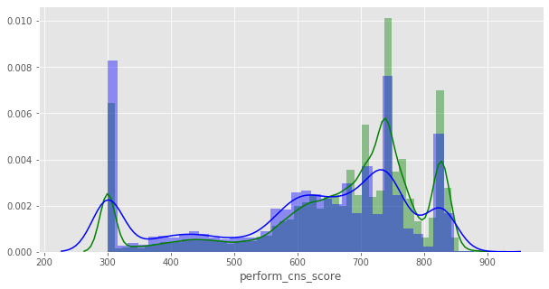

```python
plt.figure(figsize = (10,5))
sns.distplot(data[(data.loan_default == 0)& (data.perform_cns_score >=100)].perform_cns_score, color = 'green')
sns.distplot(data[(data.loan_default == 1) & (data.perform_cns_score >=100)].perform_cns_score, color = 'blue')
plt.show()
```

## For both the defaluters and non Defaulters the distribution of CNS score follow a similar distribution

```python
data['perform_cat']= pd.cut(data.perform_cns_score,
        bins = range(-1,901,100),
       labels = [0,1,2,3,4,5,6,7,8])
```

[output not shown]

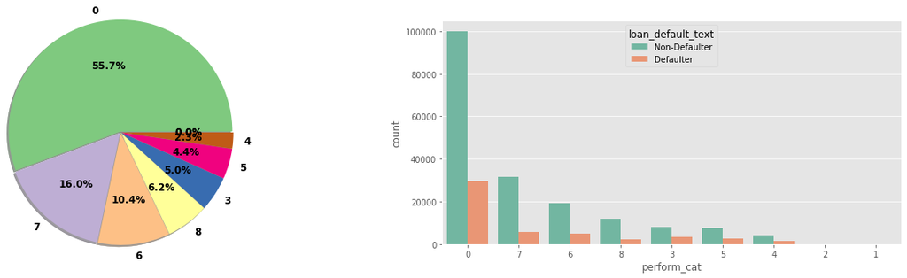

```python
f,ax = plt.subplots(1,2, figsize = (22,5))
vc = data.perform_cat.value_counts()
vc.plot.pie(cmap ='Accent', autopct = '%0.1f%%', radius = 1.25, explode = [0.01]*len(vc), shadow = True,
                    textprops = {'family': 'times','color': 'black','weight': 'bold','size': 12}, ax = ax[0])
ax[0].set_ylabel('')
sns.countplot(data.perform_cat, hue = data.loan_default_text, order = vc.index, palette='Set2', ax = ax[1])
plt.show()
```

- However looking at the Perform category variable vvs target apart from not scored applicants highest share is applicants with a higher CNS Score - > 700 - 800 CNS score.
- there area no applicants with CNS Score - 100 to 300

#### re categorising the variable

```python
data["perform_score"] = 'No Score'
data.loc[data.perform_cns_score_description.str.contains('High'),'perform_score'] = "High"
data.loc[data.perform_cns_score_description.str.contains('Very High'),'perform_score'] = "Very High"
data.loc[data.perform_cns_score_description.str.contains('Low'),'perform_score'] = "Low"
data.loc[data.perform_cns_score_description.str.contains('Very Low'),'perform_score'] = "Very Low"
data.loc[data.perform_cns_score_description.str.contains('Medium'),'perform_score'] = "Medium"
```

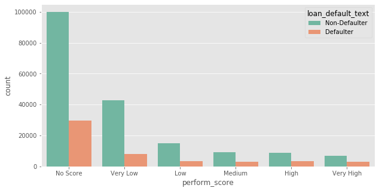

```python
plt.figure(figsize=(10,5))
sns.countplot(x='perform_score',hue='loan_default_text',data=data, palette='Set2')
plt.show()
```

[output not shown]

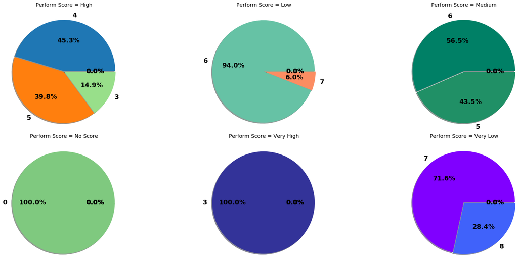

```python
cmap = ['tab20','Set2','summer','Accent','terrain', 'rainbow','Paired']
perf_cat = list(data.perform_score.unique())
perf_cat.sort()
f,ax = plt.subplots(2,int(data.perform_score.nunique()/2),figsize = (25,10))
k = 0
for j in range(2):
    for i in range(int(len(perf_cat)/2)):
        subdata = data[data.perform_score==perf_cat[k]].copy()
        vc = subdata.perform_cat.value_counts()
        vc.plot.pie(cmap =cmap[k], autopct = '%0.1f%%', radius = 1.25, explode = [0.01]*len(vc), shadow = True,
                        textprops = {'family': 'times','color': 'black','weight': 'bold','size': 18}, ax = ax[j,i])
        ax[j,i].set_ylabel('')
        ax[j,i].set_title('Perform Score = '+str(perf_cat[k])+'\n\n')
        k += 1
plt.tight_layout(w_pad = 1)
```

## ...................................................................................................................................................................................

## Explore the primary and secondary account details. Is the information in some way related to loan default probability ?

```python
pri_account_info = data.columns[data.columns.str.contains('pri')]
```

## exploring the primary account details

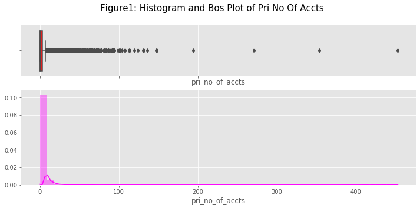

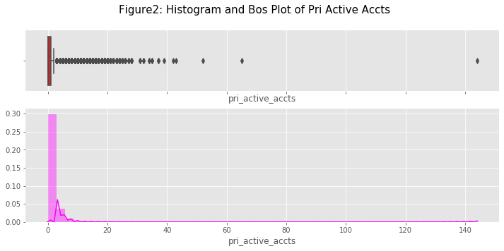

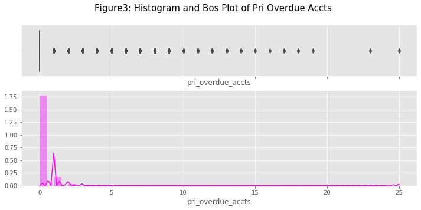

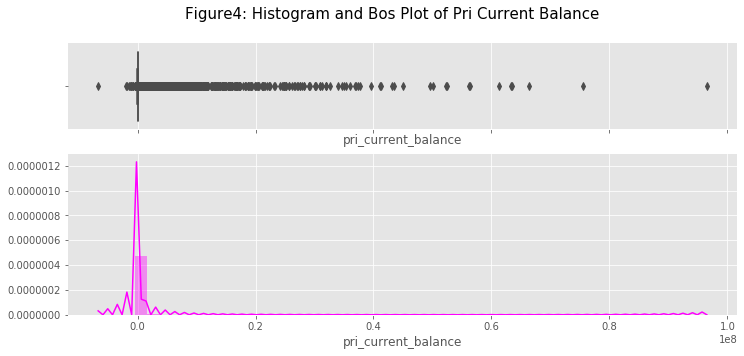

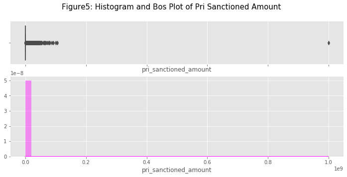

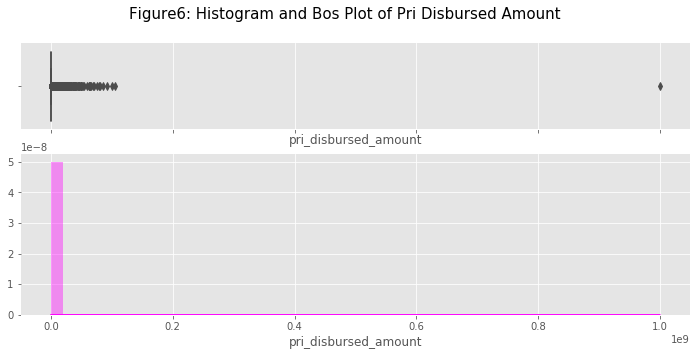

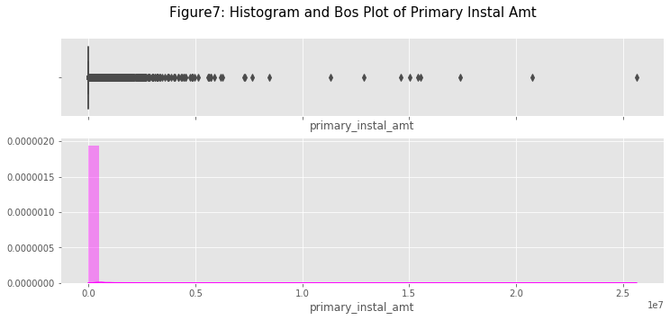

```python
i = 1
for col in pri_account_info:
    f, (ax_box, ax_hist) = plt.subplots(2,1, figsize = (12,5),sharex = True, gridspec_kw={'height_ratios':(0.35,0.65)})
    plt.suptitle('Figure' + str(i) + ': Histogram and Bos Plot of ' + col.replace('_',' ').title(), fontsize = 15)
    sns.boxplot(data[col], ax= ax_box,color = 'red')
    sns.distplot(data[col], ax = ax_hist, color = 'magenta')
    sns.despine(ax = ax_box, left = True)
    sns.despine(ax= ax_hist, left = True)
    i = i+1
    plt.show()
```